# HASAN ALP YILDIZLAR 2018402201

# IE 360 HW1

In this homework, I search for relations between commercial loan interests, unemployment rate, exchange rates and closed joint stock companies for each monnth between 01-2010 and 01-2022

I used different data from EVDS and Google Trends. I searched for "dükkan kapatma" in Google Trends

# Data preparation for visualization

# Loading packages

```r
install.packages('openxlsx')
install.packages('ggplot2')
install.packages('data.table')
install.packages('skimr')
install.packages('GGally')
install.packages('ggcorrplot')
install.packages('forecast')
install.packages('lubridate')
install.packages('zoo')
```

# Data Gathering

Data sets are downloaded from EVDS and merged as "newdataframe". Dates are converted into standart format. Columns names are assigned with "colnames() function.

```r
require(openxlsx)
require(ggplot2)
require(data.table)
require(skimr)
require(GGally)
require(ggcorrplot)
require(forecast)
library(lubridate)
library(zoo)
```

```r
closedjointstockcompanies<-read.xlsx("closedjointstockcompanies.xlsx")
closedjointstockcompanies$Dates<-paste0(closedjointstockcompanies$Dates, rep("-15",length(closedjointstockcompanies$Dates)))
closedjointstockcompanies$Dates<-as.Date(closedjointstockcompanies$Dates)
```

```r
commercialloaninterest<-read.xlsx("commercialloaninterest.xlsx")
commercialloaninterest$Dates<-paste0(commercialloaninterest$Dates, rep("-15",length(commercialloaninterest$Dates)))
commercialloaninterest$Dates<-as.Date(commercialloaninterest$Dates)
```

```r
exchangerates<-read.xlsx("exchangerates.xlsx")
exchangerates$Dates<-paste0(exchangerates$Dates, rep("-15",length(exchangerates$Dates)))
exchangerates$Dates<-as.Date(exchangerates$Dates)
```

```r
UnemploymentRate<-read.xlsx("UnemploymentRate.xlsx")
UnemploymentRate$Dates<-paste0(UnemploymentRate$Dates, rep("-15",length(UnemploymentRate$Dates)))
UnemploymentRate$Dates<-as.Date(UnemploymentRate$Dates)
```

```r
googledukkankapatma<-read.xlsx("googledukkankapatma.xlsx")
googledukkankapatma$Dates<-paste0(googledukkankapatma$Dates, rep("-15",length(googledukkankapatma$Dates)))
googledukkankapatma$Dates<-as.Date(googledukkankapatma$Dates)
```

```r
newdataframe<-data.frame(cbind(closedjointstockcompanies$Dates,closedjointstockcompanies$Number,commercialloaninterest$Rate,exchangerates$Rate,UnemploymentRate$Ratio))
newdataframe$X1<-as.Date(newdataframe$X1)
```

```r
colnames(newdataframe)<-c("Dates","closedjointstockcompanies", "commercialloaninterest","exchangerates","UnemploymentRate")
```

# Data Visualization

1) Commercial Loan interest Plot via ggplot

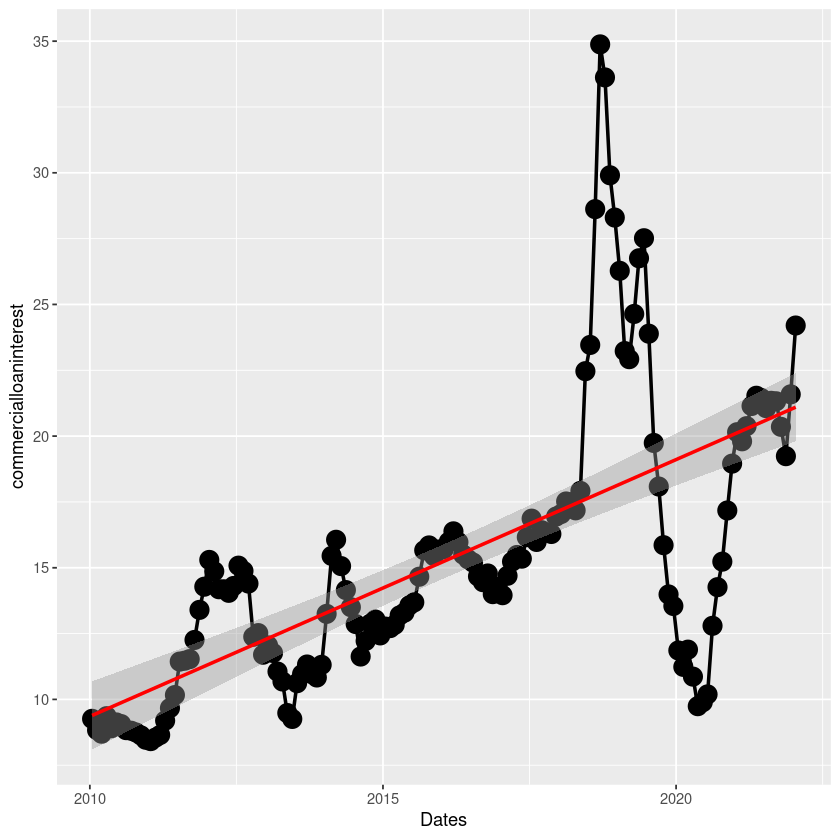

```r
a <- ggplot(data=newdataframe)+geom_line(mapping=aes(x=Dates,y=commercialloaninterest),size=1)+
  geom_point(mapping=aes(x=Dates,y=commercialloaninterest),size=5)
a+   geom_smooth(mapping=aes(x=Dates,y=commercialloaninterest),method = lm, color = "red")
```

We can observe an increasing trend with fluctuations, smoothing line helps us to visualize the data.A abrupt increse in 2018 stems from change in Central Bank's policy. Also we can see the effect of the decision that reduce interest rates in 2020 due to COVID-19 pandemic.

2) Exchange Rates via ggplot

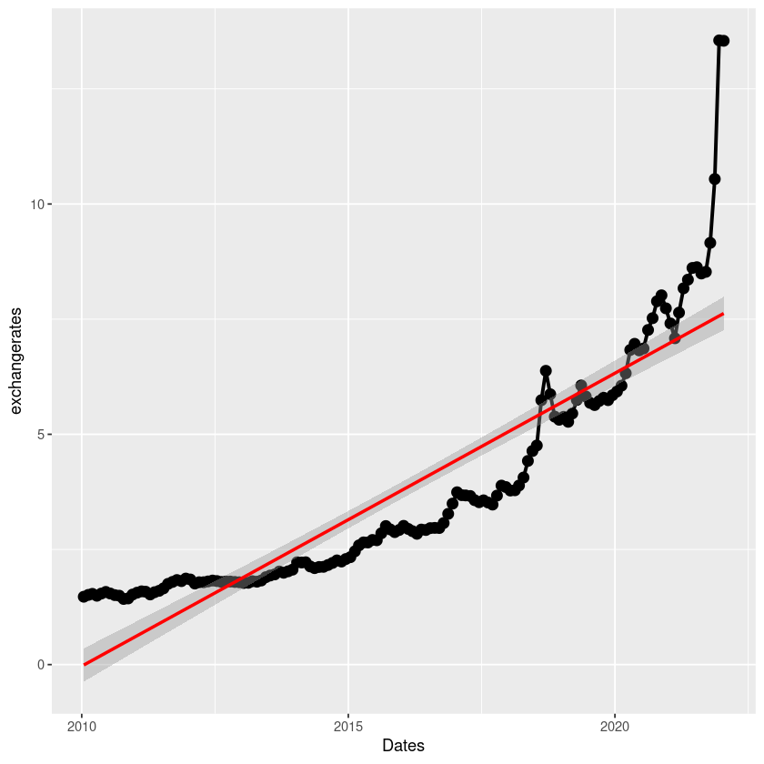

```r
a <- ggplot(data=newdataframe)+geom_line(mapping=aes(x=Dates,y=exchangerates),size=1.1,)+
  geom_point(mapping=aes(x=Dates,y=exchangerates),size=3)
  a+   geom_smooth(mapping=aes(x=Dates,y=exchangerates),method = lm, color = "red")
```

A obvious increasing trend can be seen.

3) Unemployment Rate via ggplot

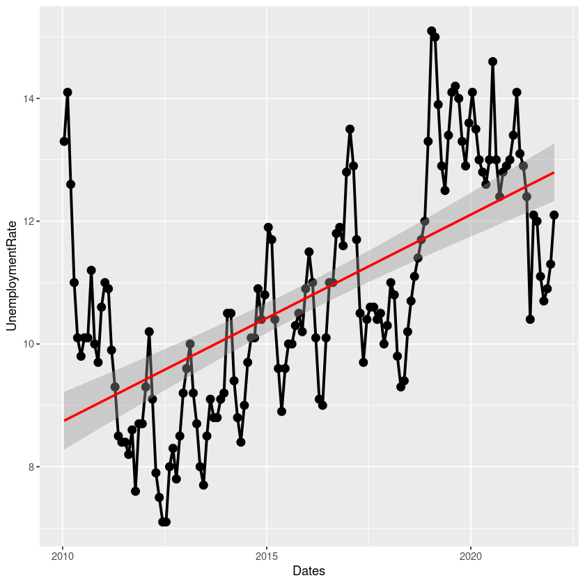

```r
a <- ggplot(data=newdataframe)+geom_line(mapping=aes(x=Dates,y=UnemploymentRate),size=1.1)+
  geom_point(mapping=aes(x=Dates,y=UnemploymentRate),size=3)
  a+   geom_smooth(mapping=aes(x=Dates,y=UnemploymentRate),method = lm, color = "red")
```

We can see the increasing trend.Also when the effects of pandemic is decreased , we can observe a drop in unemployment rates. Variance is significantly high.The data shows that unemployment rate varies from month to month.

4) Closed Joint Stock Companies

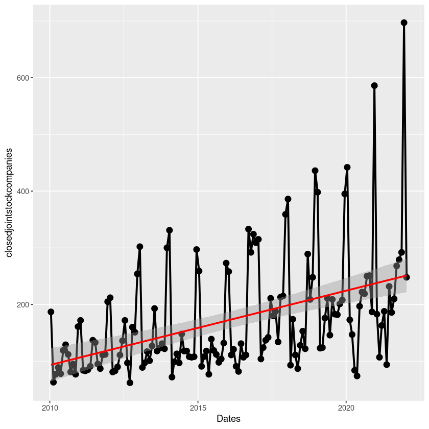

```r
a <- ggplot(data=newdataframe)+geom_line(mapping=aes(x=Dates,y=closedjointstockcompanies),size=1.1)+
  geom_point(mapping=aes(x=Dates,y=closedjointstockcompanies),size=3)
  a+   geom_smooth(mapping=aes(x=Dates,y=closedjointstockcompanies),method = lm, color = "red")
```

A increasing trend can be seen.Also varince becomes larger and larger.We can observe the effects of economy of Turkey.

# Relations Between Data

1) Closed Joint Stock Companies and Commercial Loan Interest

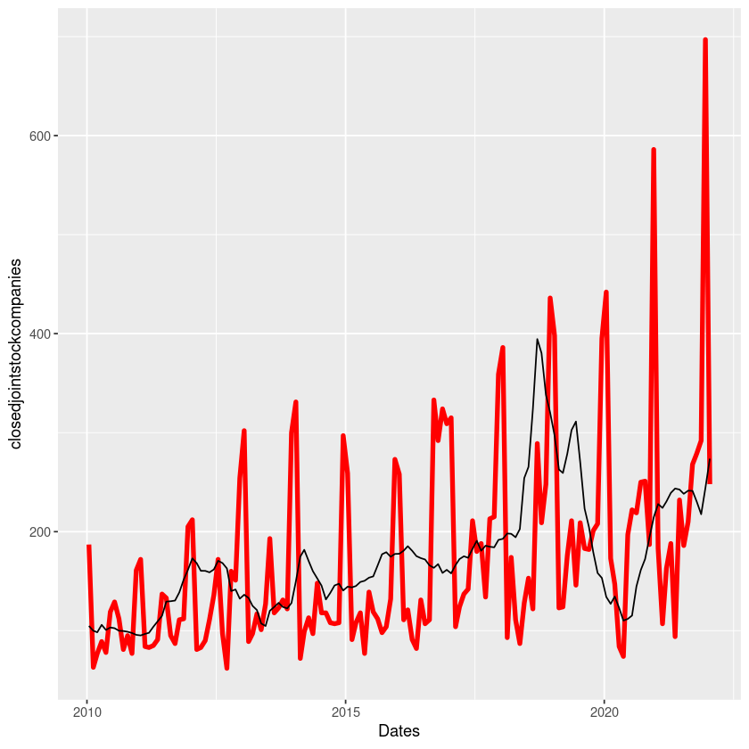

```r
scale2<-mean(newdataframe$closedjointstockcompanies)/mean(newdataframe$commercialloaninterest)

ggplot(data=newdataframe, aes(x=Dates))+geom_line(aes(y=closedjointstockcompanies),size=1.5,colour="red")+ geom_line(aes(y=commercialloaninterest*scale2))
```

In the plot , the black lines represent the commercial loan interest and the red line represents the closed joint stock companies. They both have incresing trends with increasing variance

2) Closed Joint Stock Companies and Unemployment Rate

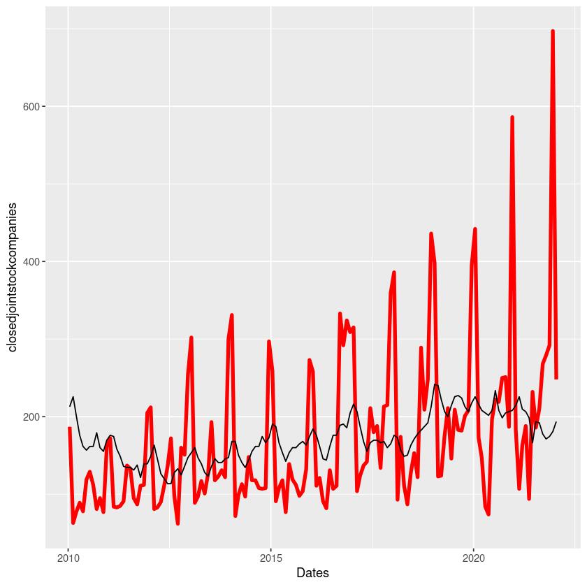

```r
scale2<-mean(newdataframe$closedjointstockcompanies)/mean(newdataframe$UnemploymentRate)

ggplot(data=newdataframe, aes(x=Dates))+geom_line(aes(y=closedjointstockcompanies),size=1.5,colour="red")+ geom_line(aes(y=UnemploymentRate*scale2))
```

The plot above displays plot of closed joint stock companies versus Unemployment Rate. As we can imagine, when the componies are closed unemployment rates increase and vice versa.

3) Closed Joint Stock Companies and Exchange Rate

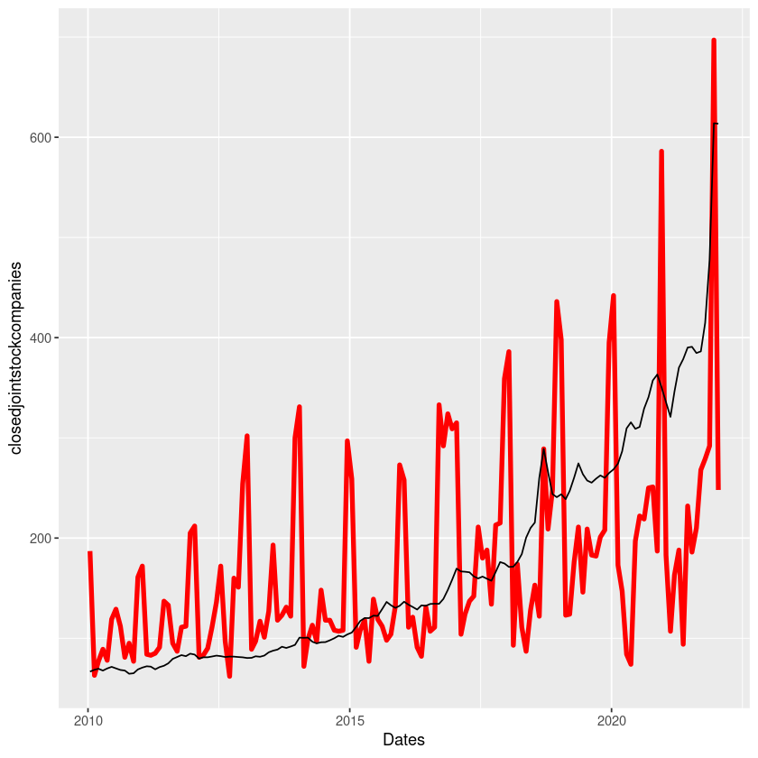

```r
scale2<-mean(newdataframe$closedjointstockcompanies)/mean(newdataframe$exchangerates)

ggplot(data=newdataframe, aes(x=Dates))+geom_line(aes(y=closedjointstockcompanies),size=1.5,colour="red")+ geom_line(aes(y=exchangerates*scale2))
```

We can observe positive correlation between these 2 datasets. Exchange rates effects companies in a bad way, as a result componies are closed.

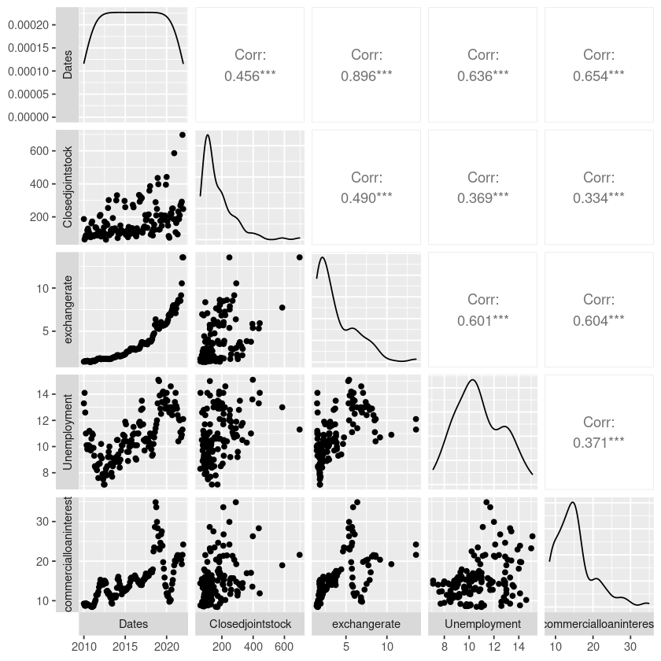

```r
alldata = read.xlsx("alldata.xlsx")
alldata$Dates = paste0(alldata$Dates, rep("-01",length(alldata$Dates)))
alldata$Dates = as.Date(alldata$Dates)
alldata[,1]=as.Date(alldata[,1])
ggpairs(alldata,switch='both')
```

When we examine the ggpair plot, we can see that all datasets are correlated with "closed joint stock companies". They are all positively correlated which means when one of them increase, other increase.

```r
# Conclusion
```

We see that the number of closed joint stock companies are related with exchange rate, unemployment rate, commercial loan interest.